# Project 3 : Supervised Machine Learning - Classification

## Objective

The main objective of my analysis is to focus on prediction that the person would be dead or alive based on the covid and health conditions given in the dataset.

# Dataset

sex: 1 for female and 2 for male. age: of the patient. classification: covid test findings. Values 1-3 mean that the patient was diagnosed with covid in different degrees. 4 or higher means that the patient is not a carrier of covid or that the test is inconclusive. patient type: type of care the patient received in the unit. 1 for returned home and 2 for hospitalization. pneumonia: whether the patient already have air sacs inflammation or not. pregnancy: whether the patient is pregnant or not. diabetes: whether the patient has diabetes or not. copd: Indicates whether the patient has Chronic obstructive pulmonary disease or not. asthma: whether the patient has asthma or not. inmsupr: whether the patient is immunosuppressed or not. hypertension: whether the patient has hypertension or not. cardiovascular: whether the patient has heart or blood vessels related disease. renal chronic: whether the patient has chronic renal disease or not. other disease: whether the patient has other disease or not. obesity: whether the patient is obese or not. tobacco: whether the patient is a tobacco user. usmer: Indicates whether the patient treated medical units of the first, second or third level. medical unit: type of institution of the National Health System that provided the care. intubed: whether the patient was connected to the ventilator. icu: Indicates whether the patient had been admitted to an Intensive Care Unit. date died: If the patient died indicate the date of death, and 9999-99-99 otherwise.

Dependant Variable :

alive : it will be created during EDA through Date_died, Whether Patient died or not.

#### Import Packages

```python
import numpy as np
import pandas as pd
import matplotlib.pyplot as plt
import seaborn as sns
from collections import Counter

from sklearn.preprocessing import OrdinalEncoder
from sklearn.feature_selection import chi2, SelectFromModel, SelectKBest
from sklearn.model_selection import train_test_split
from sklearn.linear_model import LogisticRegression
from sklearn.tree import DecisionTreeClassifier
from sklearn.ensemble import RandomForestClassifier
from xgboost import XGBClassifier
from sklearn.metrics import classification_report, roc_auc_score, ConfusionMatrixDisplay, confusion_matrix, precision_recall_fscore_support
from sklearn.model_selection import GridSearchCV
from imblearn.over_sampling import SMOTE, ADASYN
```

```python
#Load the dataset
data= pd.read_csv("Covid Data.csv")
data
```

|  | USMER | MEDICAL_UNIT | SEX | PATIENT_TYPE | DATE_DIED | INTUBED | PNEUMONIA | AGE | PREGNANT | DIABETES | ... | ASTHMA | INMSUPR | HIPERTENSION | OTHER_DISEASE | CARDIOVASCULAR | OBESITY | RENAL_CHRONIC | TOBACCO | CLASIFFICATION_FINAL | ICU |
| --- | --- | --- | --- | --- | --- | --- | --- | --- | --- | --- | --- | --- | --- | --- | --- | --- | --- | --- | --- | --- | --- |
| 0 | 2 | 1 | 1 | 1 | 03/05/2020 | 97 | 1 | 65 | 2 | 2 | ... | 2 | 2 | 1 | 2 | 2 | 2 | 2 | 2 | 3 | 97 |
| 1 | 2 | 1 | 2 | 1 | 03/06/2020 | 97 | 1 | 72 | 97 | 2 | ... | 2 | 2 | 1 | 2 | 2 | 1 | 1 | 2 | 5 | 97 |
| 2 | 2 | 1 | 2 | 2 | 09/06/2020 | 1 | 2 | 55 | 97 | 1 | ... | 2 | 2 | 2 | 2 | 2 | 2 | 2 | 2 | 3 | 2 |
| 3 | 2 | 1 | 1 | 1 | 12/06/2020 | 97 | 2 | 53 | 2 | 2 | ... | 2 | 2 | 2 | 2 | 2 | 2 | 2 | 2 | 7 | 97 |
| 4 | 2 | 1 | 2 | 1 | 21/06/2020 | 97 | 2 | 68 | 97 | 1 | ... | 2 | 2 | 1 | 2 | 2 | 2 | 2 | 2 | 3 | 97 |
| ... | ... | ... | ... | ... | ... | ... | ... | ... | ... | ... | ... | ... | ... | ... | ... | ... | ... | ... | ... | ... | ... |
| 1048570 | 2 | 13 | 2 | 1 | 9999-99-99 | 97 | 2 | 40 | 97 | 2 | ... | 2 | 2 | 2 | 2 | 2 | 2 | 2 | 2 | 7 | 97 |
| 1048571 | 1 | 13 | 2 | 2 | 9999-99-99 | 2 | 2 | 51 | 97 | 2 | ... | 2 | 2 | 1 | 2 | 2 | 2 | 2 | 2 | 7 | 2 |
| 1048572 | 2 | 13 | 2 | 1 | 9999-99-99 | 97 | 2 | 55 | 97 | 2 | ... | 2 | 2 | 2 | 2 | 2 | 2 | 2 | 2 | 7 | 97 |
| 1048573 | 2 | 13 | 2 | 1 | 9999-99-99 | 97 | 2 | 28 | 97 | 2 | ... | 2 | 2 | 2 | 2 | 2 | 2 | 2 | 2 | 7 | 97 |
| 1048574 | 2 | 13 | 2 | 1 | 9999-99-99 | 97 | 2 | 52 | 97 | 2 | ... | 2 | 2 | 2 | 2 | 2 | 2 | 2 | 2 | 7 | 97 |

1048575 rows × 21 columns

### EDA

#### Observation

- There are no null values in any column
- The dataset is very unbalanced as almost every column has a majority class with larger imbalance ratio.

```python
data.info()
```

```
<class 'pandas.core.frame.DataFrame'>
RangeIndex: 1048575 entries, 0 to 1048574
Data columns (total 21 columns):
 #   Column                Non-Null Count    Dtype
---  ------                --------------    -----
 0   USMER                 1048575 non-null  int64
 1   MEDICAL_UNIT          1048575 non-null  int64
 2   SEX                   1048575 non-null  int64
 3   PATIENT_TYPE          1048575 non-null  int64
 4   DATE_DIED             1048575 non-null  object
 5   INTUBED               1048575 non-null  int64
 6   PNEUMONIA             1048575 non-null  int64
 7   AGE                   1048575 non-null  int64
 8   PREGNANT              1048575 non-null  int64
 9   DIABETES              1048575 non-null  int64
 10  COPD                  1048575 non-null  int64
 11  ASTHMA                1048575 non-null  int64
 12  INMSUPR               1048575 non-null  int64
 13  HIPERTENSION          1048575 non-null  int64
 14  OTHER_DISEASE         1048575 non-null  int64
 15  CARDIOVASCULAR        1048575 non-null  int64
 16  OBESITY               1048575 non-null  int64
 17  RENAL_CHRONIC         1048575 non-null  int64
 18  TOBACCO               1048575 non-null  int64
 19  CLASIFFICATION_FINAL  1048575 non-null  int64
 20  ICU                   1048575 non-null  int64
dtypes: int64(20), object(1)
memory usage: 168.0+ MB
```

```python
for column in data.columns:
    print(data[column].value_counts(), end="\n\n")
```

```
USMER
2    662903
1    385672
Name: count, dtype: int64

MEDICAL_UNIT
12    602995
4     314405
6      40584
9      38116
3      19175
8      10399
10      7873
5       7244
11      5577
13       996
7        891
2        169
1        151
Name: count, dtype: int64

SEX
1    525064
2    523511
Name: count, dtype: int64

PATIENT_TYPE
1    848544
2    200031
Name: count, dtype: int64

DATE_DIED
9999-99-99    971633
06/07/2020      1000
07/07/2020       996
13/07/2020       990
16/06/2020       979
               ...
24/11/2020         1
17/12/2020         1
```

[output cut: 100 more lines]

```
7    499250
3    381527
6    128133
5     26091
1      8601
4      3122
2      1851
Name: count, dtype: int64

ICU
97    848544
2     175685
1      16858
99      7488
Name: count, dtype: int64
```

```python
data['Alive'] = data['DATE_DIED'].apply(lambda x: 1 if x =='9999-99-99' else 2)
```

```python
data['Alive'].value_counts()
```

```
Alive
1    971633
2     76942
Name: count, dtype: int64
```

```python
mask = data['PREGNANT'].isin([97, 98, 99])
data['PREGNANT'] = data['PREGNANT'].mask(mask & (data['SEX'] == 1), None)
data['PREGNANT'] = data['PREGNANT'].mask(mask & (data['SEX'] == 2), 2)
data.loc[data['PATIENT_TYPE'] == 1, ['INTUBED', 'ICU']] = 2
refined_data = data.replace(to_replace=[97,98,99], value=None)
refined_data['AGE']= data['AGE']
```

```python
refined_data.dropna(inplace=True)
refined_data
```

|  | USMER | MEDICAL_UNIT | SEX | PATIENT_TYPE | DATE_DIED | INTUBED | PNEUMONIA | AGE | PREGNANT | DIABETES | ... | INMSUPR | HIPERTENSION | OTHER_DISEASE | CARDIOVASCULAR | OBESITY | RENAL_CHRONIC | TOBACCO | CLASIFFICATION_FINAL | ICU | Alive |
| --- | --- | --- | --- | --- | --- | --- | --- | --- | --- | --- | --- | --- | --- | --- | --- | --- | --- | --- | --- | --- | --- |
| 0 | 2 | 1 | 1 | 1 | 03/05/2020 | 2 | 1 | 65 | 2.0 | 2 | ... | 2 | 1 | 2 | 2 | 2 | 2 | 2 | 3 | 2 | 2 |
| 1 | 2 | 1 | 2 | 1 | 03/06/2020 | 2 | 1 | 72 | 2.0 | 2 | ... | 2 | 1 | 2 | 2 | 1 | 1 | 2 | 5 | 2 | 2 |
| 2 | 2 | 1 | 2 | 2 | 09/06/2020 | 1 | 2 | 55 | 2.0 | 1 | ... | 2 | 2 | 2 | 2 | 2 | 2 | 2 | 3 | 2 | 2 |
| 3 | 2 | 1 | 1 | 1 | 12/06/2020 | 2 | 2 | 53 | 2.0 | 2 | ... | 2 | 2 | 2 | 2 | 2 | 2 | 2 | 7 | 2 | 2 |
| 4 | 2 | 1 | 2 | 1 | 21/06/2020 | 2 | 2 | 68 | 2.0 | 1 | ... | 2 | 1 | 2 | 2 | 2 | 2 | 2 | 3 | 2 | 2 |
| ... | ... | ... | ... | ... | ... | ... | ... | ... | ... | ... | ... | ... | ... | ... | ... | ... | ... | ... | ... | ... | ... |
| 1048570 | 2 | 13 | 2 | 1 | 9999-99-99 | 2 | 2 | 40 | 2.0 | 2 | ... | 2 | 2 | 2 | 2 | 2 | 2 | 2 | 7 | 2 | 1 |
| 1048571 | 1 | 13 | 2 | 2 | 9999-99-99 | 2 | 2 | 51 | 2.0 | 2 | ... | 2 | 1 | 2 | 2 | 2 | 2 | 2 | 7 | 2 | 1 |
| 1048572 | 2 | 13 | 2 | 1 | 9999-99-99 | 2 | 2 | 55 | 2.0 | 2 | ... | 2 | 2 | 2 | 2 | 2 | 2 | 2 | 7 | 2 | 1 |
| 1048573 | 2 | 13 | 2 | 1 | 9999-99-99 | 2 | 2 | 28 | 2.0 | 2 | ... | 2 | 2 | 2 | 2 | 2 | 2 | 2 | 7 | 2 | 1 |
| 1048574 | 2 | 13 | 2 | 1 | 9999-99-99 | 2 | 2 | 52 | 2.0 | 2 | ... | 2 | 2 | 2 | 2 | 2 | 2 | 2 | 7 | 2 | 1 |

1019666 rows × 22 columns

```python
for column in refined_data.columns:
    print(refined_data[column].value_counts(), end="\n\n")
```

```
USMER
2    655076
1    364590
Name: count, dtype: int64

MEDICAL_UNIT
12    587800
4     306502
6      37675
9      36983
3      18566
8      10070
10      7511
5       7045
11      5541
7        856
13       808
2        158
1        151
Name: count, dtype: int64

SEX
2    510596
1    509070
Name: count, dtype: int64

PATIENT_TYPE
1    830385
2    189281
Name: count, dtype: int64

DATE_DIED
9999-99-99    946356
06/07/2020       966
07/07/2020       963
13/07/2020       947
16/06/2020       937
               ...
10/09/2020         1
19/04/2021         1
```

[output cut: 88 more lines]

```
5     25175
1      8397
4      3082
2      1783
Name: count, dtype: int64

ICU
2    1003258
1      16408
Name: count, dtype: int64

Alive
1    946356
2     73310
Name: count, dtype: int64
```

```python
# Define age groups
bins = [0, 12, 18, 35, 50, 65, 80,125]
labels = ['Child', 'Teen', 'Young Adult', 'Adult', 'Middle-aged', 'Senior', 'Elderly']

# Apply binning
refined_data['Age Group'] = pd.cut(refined_data['AGE'], bins=bins, labels=labels, right=False)
# Ordinal Encoding
encoder = OrdinalEncoder(categories=[labels])  # Preserve order
refined_data['Age Group'] = encoder.fit_transform(refined_data[['Age Group']])

refined_data
```

|  | USMER | MEDICAL_UNIT | SEX | PATIENT_TYPE | DATE_DIED | INTUBED | PNEUMONIA | AGE | PREGNANT | DIABETES | ... | HIPERTENSION | OTHER_DISEASE | CARDIOVASCULAR | OBESITY | RENAL_CHRONIC | TOBACCO | CLASIFFICATION_FINAL | ICU | Alive | Age Group |
| --- | --- | --- | --- | --- | --- | --- | --- | --- | --- | --- | --- | --- | --- | --- | --- | --- | --- | --- | --- | --- | --- |
| 0 | 2 | 1 | 1 | 1 | 03/05/2020 | 2 | 1 | 65 | 2.0 | 2 | ... | 1 | 2 | 2 | 2 | 2 | 2 | 3 | 2 | 2 | 5.0 |
| 1 | 2 | 1 | 2 | 1 | 03/06/2020 | 2 | 1 | 72 | 2.0 | 2 | ... | 1 | 2 | 2 | 1 | 1 | 2 | 5 | 2 | 2 | 5.0 |
| 2 | 2 | 1 | 2 | 2 | 09/06/2020 | 1 | 2 | 55 | 2.0 | 1 | ... | 2 | 2 | 2 | 2 | 2 | 2 | 3 | 2 | 2 | 4.0 |
| 3 | 2 | 1 | 1 | 1 | 12/06/2020 | 2 | 2 | 53 | 2.0 | 2 | ... | 2 | 2 | 2 | 2 | 2 | 2 | 7 | 2 | 2 | 4.0 |
| 4 | 2 | 1 | 2 | 1 | 21/06/2020 | 2 | 2 | 68 | 2.0 | 1 | ... | 1 | 2 | 2 | 2 | 2 | 2 | 3 | 2 | 2 | 5.0 |
| ... | ... | ... | ... | ... | ... | ... | ... | ... | ... | ... | ... | ... | ... | ... | ... | ... | ... | ... | ... | ... | ... |
| 1048570 | 2 | 13 | 2 | 1 | 9999-99-99 | 2 | 2 | 40 | 2.0 | 2 | ... | 2 | 2 | 2 | 2 | 2 | 2 | 7 | 2 | 1 | 3.0 |
| 1048571 | 1 | 13 | 2 | 2 | 9999-99-99 | 2 | 2 | 51 | 2.0 | 2 | ... | 1 | 2 | 2 | 2 | 2 | 2 | 7 | 2 | 1 | 4.0 |
| 1048572 | 2 | 13 | 2 | 1 | 9999-99-99 | 2 | 2 | 55 | 2.0 | 2 | ... | 2 | 2 | 2 | 2 | 2 | 2 | 7 | 2 | 1 | 4.0 |
| 1048573 | 2 | 13 | 2 | 1 | 9999-99-99 | 2 | 2 | 28 | 2.0 | 2 | ... | 2 | 2 | 2 | 2 | 2 | 2 | 7 | 2 | 1 | 2.0 |
| 1048574 | 2 | 13 | 2 | 1 | 9999-99-99 | 2 | 2 | 52 | 2.0 | 2 | ... | 2 | 2 | 2 | 2 | 2 | 2 | 7 | 2 | 1 | 4.0 |

1019666 rows × 23 columns

```python
refined_data.drop(columns=['DATE_DIED','AGE'], axis=1,inplace=True)
```

#### Observations

- With respect to 'Alive' we have 'PNEUMONIA', 'INTUBED','PATIENT_TYPE','Age Group' are most prominent features.
- But as the dataset is unbalanced corr might not help much in feature selection.

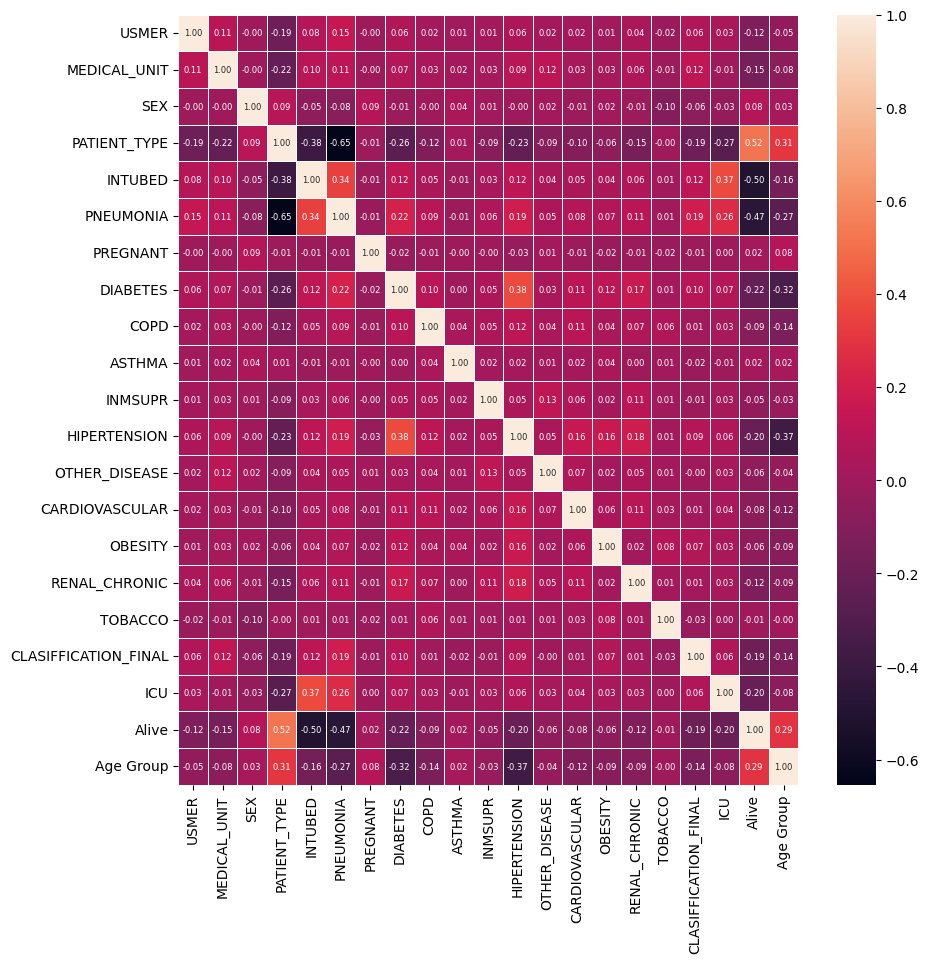

```python
plt.figure(figsize=(10, 10))
sns.heatmap(refined_data.corr(method='spearman'), annot=True,  fmt=".2f",linewidths=0.5, annot_kws={"size": 6})
plt.show()
```

```python
discrete_features = refined_data.columns
```

#### Observation

- We could see it is diificult to make prediction for 'Alive' as value count is almost similar in ratio with all classes.
- 'PNEUMONIA', 'INTUBED', 'Age Group' shows a major differentiation.

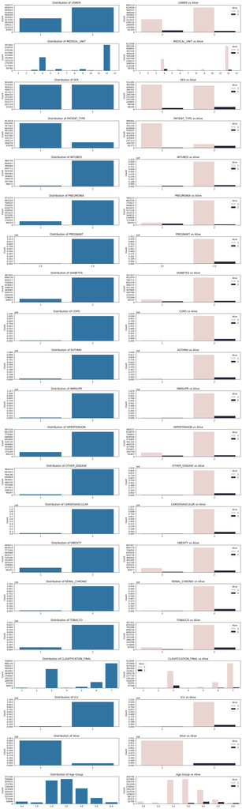

```python
# Define the number of features and set a dynamic height
num_features = len(discrete_features)
fig, ax = plt.subplots(num_features, 2, figsize=(16, num_features * 2.5))  # Increase height dynamically

for i, feature in enumerate(discrete_features):
    # Plot countplot without hue
    sns.countplot(ax=ax[i, 0], x=feature, data=refined_data)
    ax[i, 0].set_title(f"Distribution of {feature}", fontsize=12)
    ax[i, 0].set_xlabel("")
    ax[i, 0].set_ylabel("Count", fontsize=10)

    # Plot countplot with 'Alive' hue
    sns.countplot(ax=ax[i, 1], x=feature, hue='Alive', data=refined_data)
    ax[i, 1].set_title(f"{feature} vs Alive", fontsize=12)
    ax[i, 1].set_xlabel("")
    ax[i, 1].set_ylabel("Count", fontsize=10)

    # Set y-axis ticks dynamically
    max_count = refined_data[feature].value_counts().max()
    tick_interval = max(1, max_count // 10)  # Set dynamic interval for better spacing
    ax[i, 0].set_yticks(range(0, max_count + tick_interval, tick_interval))

    # Set y-axis tick spacing dynamically for the second plot (based on hue)
    max_count_2 = refined_data.groupby(feature)['Alive'].value_counts().max()
    tick_interval_2 = max(1, max_count_2 // 10)
    ax[i, 1].set_yticks(range(0, max_count_2 + tick_interval_2, tick_interval_2))

plt.subplots_adjust(hspace=0.5, wspace=0.3)  # Increase spacing between subplots
fig.tight_layout(pad=2)
plt.show()
```

#### Observation

- We could see the top features

  Age Group : 43822.594537976875  
  MEDICAL_UNIT : 37796.72489121804  
  PATIENT_TYPE : 34859.798318027286  
  CLASIFFICATION_FINAL : 26083.104291404423  
  PNEUMONIA : 14077.887325773387  
  INTUBED : 4130.213961265305  
  HIPERTENSION : 2994.5650815717036  
  DIABETES : 2649.2413529553733  
  USMER : 1973.9843896470545  
  SEX : 1085.1027848188737

```python
x = refined_data.drop(['Alive'], axis=1).astype(int)
y = refined_data['Alive'].astype(int)
y = y.apply(lambda v: v-1)
best_features = SelectKBest(chi2, k=10)
features_ranking = best_features.fit(x, y)
ranking_dictionary = {}
for i in range(len(features_ranking.scores_)):
    ranking_dictionary[x.columns[i]] = features_ranking.scores_[i]

asc_sort = sorted(ranking_dictionary.items(), key = lambda x:x[1],reverse=True)

for feature, score in asc_sort:
    print(feature, ':', score)
```

```
Age Group : 43822.594537976875
MEDICAL_UNIT : 37796.72489121804
PATIENT_TYPE : 34859.798318027286
CLASIFFICATION_FINAL : 26083.104291404423
PNEUMONIA : 14077.887325773387
INTUBED : 4130.213961265305
HIPERTENSION : 2994.5650815717036
DIABETES : 2649.2413529553733
USMER : 1973.9843896470545
SEX : 1085.1027848188737
ICU : 338.67464097467257
OBESITY : 219.7056593954017
RENAL_CHRONIC : 129.00281808135935
CARDIOVASCULAR : 57.432984168373984
COPD : 56.831732330119344
OTHER_DISEASE : 43.61760073301738
INMSUPR : 16.639369764568322
ASTHMA : 4.673685536567792
PREGNANT : 1.7195691419068941
TOBACCO : 1.2481071577055332
```

#### Observation and Insights

- Missing data was easily interpretable
- With increasing 'Age Group' death chances increases.
- Patient with 'PNUEMONIA', 'INTUBED' are having higher chances of death.
- Patients with 'Covid_classification as '3' are highly death prone than any other classification. That means Covid with level 3 is the most Severe and damaging.
- Overall people who had pre-diagnosed diseases have higher chances of death.
- Patients who have been hospital had severe covid condition leading to more deaths.

- Using Logistic Regression, Descision Classifier and Random Forrest modelsfor training.
- Using XGBClassifier to apply boosting for unbalanced dataset.
- as it has too many features and values KNN, and SVC are too slow and complex to fit but could use in future with selected features.
- Using SMOTE technique for resampling the class distributionn.
- Using F1 score, Recall as primary metrics as the dataset is unbalanced

```python
# Stratified train-test split (80-20 split)
X_train, X_test, y_train, y_test = train_test_split(x, y, test_size=0.2, stratify=y, random_state=123)

# Check class distribution in train & test sets
print("Train: ", y_train.value_counts(normalize=True))
print("Test: ", y_test.value_counts(normalize=True))
```

```
Train:  Alive
0    0.928104
1    0.071896
Name: proportion, dtype: float64
Test:  Alive
0    0.928104
1    0.071896
Name: proportion, dtype: float64
```

```python
lr_model = LogisticRegression(max_iter=1000, random_state=123,verbose=1)
dt_model = DecisionTreeClassifier(max_depth=25, max_features=10, random_state=123)
rf_model = RandomForestClassifier(n_estimators=150, max_depth=25, random_state=123,verbose=1)
xgb_model = XGBClassifier(n_estimators=150, random_state=123)
```

```python
X_train= X_train.astype(int)
X_test= X_test.astype(int)
y_test = y_test.astype(int)
y_train= y_train.astype(int)
```

```python
lr_model.fit(X_train,y_train)
lr_y_pred= lr_model.predict(X_test)
print('Logistic Regression Complete')

xgb_model.fit(X_train,y_train,verbose=1)
xgb_y_pred= xgb_model.predict(X_test)
print('XGB Complete')
dt_model.fit(X_train,y_train)
dt_y_pred= dt_model.predict(X_test)
print('Decision Tree Regression Complete')
rf_model.fit(X_train,y_train)
rf_y_pred= rf_model.predict(X_test)
print('Random Forrest Complete')
```

```
Logistic Regression Complete
XGB Complete
Decision Tree Regression Complete
```

```
[Parallel(n_jobs=1)]: Done  49 tasks      | elapsed:   50.3s
[Parallel(n_jobs=1)]: Done  49 tasks      | elapsed:    1.9s
```

```
Random Forrest Complete
```

```python
print('lr_model: ',roc_auc_score(y_test, lr_model.predict_proba(X_test)[:, 1]),end='\n\n')
print('dt_model: ',roc_auc_score(y_test, dt_model.predict_proba(X_test)[:, 1]),end='\n\n')
print('rf_model: ',roc_auc_score(y_test, rf_model.predict_proba(X_test)[:, 1]),end='\n\n')
print('xgb_model: ',roc_auc_score(y_test, xgb_model.predict_proba(X_test)[:, 1]),end='\n\n')


print('lr_model: ',classification_report(y_test,lr_y_pred),end='\n\n')
print('dt_model: ',classification_report(y_test,dt_y_pred),end='\n\n')
print('rf_model: ',classification_report(y_test,rf_y_pred),end='\n\n')
print('xgb_model: ',classification_report(y_test,xgb_y_pred),end='\n\n')
```

```
lr_model:  0.9611906536124379

dt_model:  0.8842313179781945
```

```
[Parallel(n_jobs=1)]: Done  49 tasks      | elapsed:    2.0s
```

```
rf_model:  0.9539316447546056

xgb_model:  0.9676899147520295

lr_model:                precision    recall  f1-score   support

           0       0.96      0.98      0.97    189272
           1       0.70      0.50      0.58     14662

    accuracy                           0.95    203934
   macro avg       0.83      0.74      0.78    203934
weighted avg       0.94      0.95      0.94    203934


dt_model:                precision    recall  f1-score   support

           0       0.96      0.98      0.97    189272
           1       0.68      0.49      0.57     14662

    accuracy                           0.95    203934
   macro avg       0.82      0.74      0.77    203934
weighted avg       0.94      0.95      0.94    203934


rf_model:                precision    recall  f1-score   support

           0       0.96      0.98      0.97    189272
           1       0.69      0.52      0.59     14662

    accuracy                           0.95    203934
   macro avg       0.83      0.75      0.78    203934
weighted avg       0.94      0.95      0.95    203934


xgb_model:                precision    recall  f1-score   support

           0       0.96      0.99      0.97    189272
           1       0.73      0.52      0.61     14662

    accuracy                           0.95    203934
   macro avg       0.85      0.75      0.79    203934
weighted avg       0.95      0.95      0.95    203934
```

```python
smote = SMOTE(sampling_strategy=0.5, random_state=123)
X_resampled, y_resampled = smote.fit_resample(X_train, y_train)
```

```python
lr_model.fit(X_resampled,y_resampled)
lr_y_pred= lr_model.predict(X_test)
print('Logistic Regression Complete')

xgb_model.fit(X_resampled,y_resampled,verbose=1)
xgb_y_pred= xgb_model.predict(X_test)
print('XGB Complete')
dt_model.fit(X_resampled,y_resampled)
dt_y_pred= dt_model.predict(X_test)
print('Decision Tree Regression Complete')
rf_model.fit(X_resampled,y_resampled)
rf_y_pred= rf_model.predict(X_test)
print('Random Forrest Complete')

print('lr_model: ',roc_auc_score(y_test, lr_model.predict_proba(X_test)[:, 1]),end='\n\n')
print('dt_model: ',roc_auc_score(y_test, dt_model.predict_proba(X_test)[:, 1]),end='\n\n')
print('rf_model: ',roc_auc_score(y_test, rf_model.predict_proba(X_test)[:, 1]),end='\n\n')
print('xgb_model: ',roc_auc_score(y_test, xgb_model.predict_proba(X_test)[:, 1]),end='\n\n')


print('lr_model: ',classification_report(y_test,lr_y_pred),end='\n\n')
print('dt_model: ',classification_report(y_test,dt_y_pred),end='\n\n')
print('rf_model: ',classification_report(y_test,rf_y_pred),end='\n\n')
print('xgb_model: ',classification_report(y_test,xgb_y_pred),end='\n\n')
```

```
Logistic Regression Complete
XGB Complete
Decision Tree Regression Complete
```

```
[Parallel(n_jobs=1)]: Done  49 tasks      | elapsed:  1.3min
[Parallel(n_jobs=1)]: Done  49 tasks      | elapsed:    1.9s
```

```
Random Forrest Complete
lr_model:  0.9611741113618207

dt_model:  0.8876410984628946
```

```
[Parallel(n_jobs=1)]: Done  49 tasks      | elapsed:    2.2s
```

```
rf_model:  0.950391577537917

xgb_model:  0.9672017062047686

lr_model:                precision    recall  f1-score   support

           0       0.99      0.92      0.95    189272
           1       0.45      0.86      0.59     14662

    accuracy                           0.92    203934
   macro avg       0.72      0.89      0.77    203934
weighted avg       0.95      0.92      0.93    203934


dt_model:                precision    recall  f1-score   support

           0       0.98      0.93      0.95    189272
           1       0.46      0.82      0.59     14662

    accuracy                           0.92    203934
   macro avg       0.72      0.87      0.77    203934
weighted avg       0.95      0.92      0.93    203934


rf_model:                precision    recall  f1-score   support

           0       0.99      0.93      0.95    189272
           1       0.46      0.83      0.60     14662

    accuracy                           0.92    203934
   macro avg       0.73      0.88      0.78    203934
weighted avg       0.95      0.92      0.93    203934


xgb_model:                precision    recall  f1-score   support

           0       0.99      0.92      0.95    189272
           1       0.45      0.90      0.60     14662

    accuracy                           0.91    203934
   macro avg       0.72      0.91      0.78    203934
weighted avg       0.95      0.91      0.93    203934
```

```python
class_weight= {0:9.2,1:0.8}
lr_model = LogisticRegression(max_iter=1000, random_state=123,verbose=1,class_weight=class_weight)
dt_model = DecisionTreeClassifier(max_depth=25, max_features=10, random_state=123,class_weight=class_weight)
rf_model = RandomForestClassifier(n_estimators=150, max_depth=25, random_state=123,verbose=1,class_weight=class_weight)
xgb_model = XGBClassifier(n_estimators=150, random_state=123)

lr_model.fit(X_train,y_train)
lr_y_pred= lr_model.predict(X_test)
print('Logistic Regression Complete')

dt_model.fit(X_train,y_train)
dt_y_pred= dt_model.predict(X_test)
print('Decision Tree Regression Complete')
rf_model.fit(X_train,y_train)
rf_y_pred= rf_model.predict(X_test)
print('Random Forrest Complete')

print('lr_model: ',roc_auc_score(y_test, lr_model.predict_proba(X_test)[:, 1]),end='\n\n')
print('dt_model: ',roc_auc_score(y_test, dt_model.predict_proba(X_test)[:, 1]),end='\n\n')
print('rf_model: ',roc_auc_score(y_test, rf_model.predict_proba(X_test)[:, 1]),end='\n\n')
# print('xgb_model: ',roc_auc_score(y_test, xgb_model.predict_proba(X_test)[:, 1]),end='\n\n')
```

```
Logistic Regression Complete
Decision Tree Regression Complete
```

```
[Parallel(n_jobs=1)]: Done  49 tasks      | elapsed:   51.9s
[Parallel(n_jobs=1)]: Done  49 tasks      | elapsed:    2.2s
```

```
Random Forrest Complete
lr_model:  0.9607487445568135

dt_model:  0.886563029397784
```

```
[Parallel(n_jobs=1)]: Done  49 tasks      | elapsed:    3.0s
```

```
rf_model:  0.9522905035171297
```

```python
print('lr_model: ',classification_report(y_test,lr_y_pred),end='\n\n')
print('dt_model: ',classification_report(y_test,dt_y_pred),end='\n\n')
print('rf_model: ',classification_report(y_test,rf_y_pred),end='\n\n')
print('xgb_model: ',classification_report(y_test,xgb_y_pred),end='\n\n')
```

```
lr_model:                precision    recall  f1-score   support

           0       0.93      1.00      0.97    189272
           1       0.93      0.08      0.15     14662

    accuracy                           0.93    203934
   macro avg       0.93      0.54      0.56    203934
weighted avg       0.93      0.93      0.91    203934


dt_model:                precision    recall  f1-score   support

           0       0.94      0.99      0.97    189272
           1       0.70      0.24      0.36     14662

    accuracy                           0.94    203934
   macro avg       0.82      0.62      0.66    203934
weighted avg       0.93      0.94      0.92    203934


rf_model:                precision    recall  f1-score   support

           0       0.95      0.99      0.97    189272
           1       0.76      0.27      0.40     14662

    accuracy                           0.94    203934
   macro avg       0.85      0.63      0.68    203934
weighted avg       0.93      0.94      0.93    203934


xgb_model:                precision    recall  f1-score   support

           0       0.99      0.92      0.95    189272
           1       0.45      0.90      0.60     14662

    accuracy                           0.91    203934
   macro avg       0.72      0.91      0.78    203934
weighted avg       0.95      0.91      0.93    203934
```

## Best Model To Choose

- XGBClassifier with Smote is the best model to choose due to high Accuracy 91 and recall 91, as we could go with False positive in this case rather than taking risk.

## Future Suggestion/Scope

- Should work on a better trade off balance for minority class in this case.
- Should Focus on Hyperparameter tuning for better results.
- More classification could be done such as predicting the level of covid through other features.